# Lab 6

[Nate E.](https://nateedgar97.github.io/)

9/10/2020

# Libraries

```r
library(sf)        # vector manipulation
library(raster)    # raster manipulation
library(fasterize) # "faster" raster
library(whitebox)  # terrain analysis
```

### Data Manipulation

```r
library(osmdata)   # OSM API
library(elevatr)   # Elevation  Web Tiles
```

# Collecting the data needed for the analysis.

This includes representations of the elevation grid, the river network, and building structures.

# Basin boundary

```r
Basin = read_sf("https://labs.waterdata.usgs.gov/api/nldi/linked-data/nwissite/USGS-11119750/basin")
```

# Elevation Data

```r
Elevation_Data = elevatr::get_elev_raster(Basin,13) %>%
  crop(Basin) %>%
  mask(Basin)

elevation_feet = Elevation_Data * 3.281

writeRaster(elevation_feet,"../data/elev_raster_feet.tif", overwrite = TRUE)
```

Overwrite is used to not get multiple copies after each run.

# Buildings and river-network data

```r
Building = osmdata::add_osm_feature(opq(Basin),"building") %>%
  osmdata_sf()



Stream = osmdata::add_osm_feature(opq(Basin),"waterway","stream") %>% osmdata_sf()


Centroid = st_centroid(Building$osm_polygons) %>%
  st_intersection(Basin)


Railroad = dplyr::filter(Centroid, amenity=="railway")


Rivers = st_intersection(Stream$osm_lines,Basin)
```

# Terrain Analysis

### For Hillshade

```r
wbt_hillshade("../data/elev_raster_feet.tif", "../data/terrian-near-flood-hillshade.tif")
```

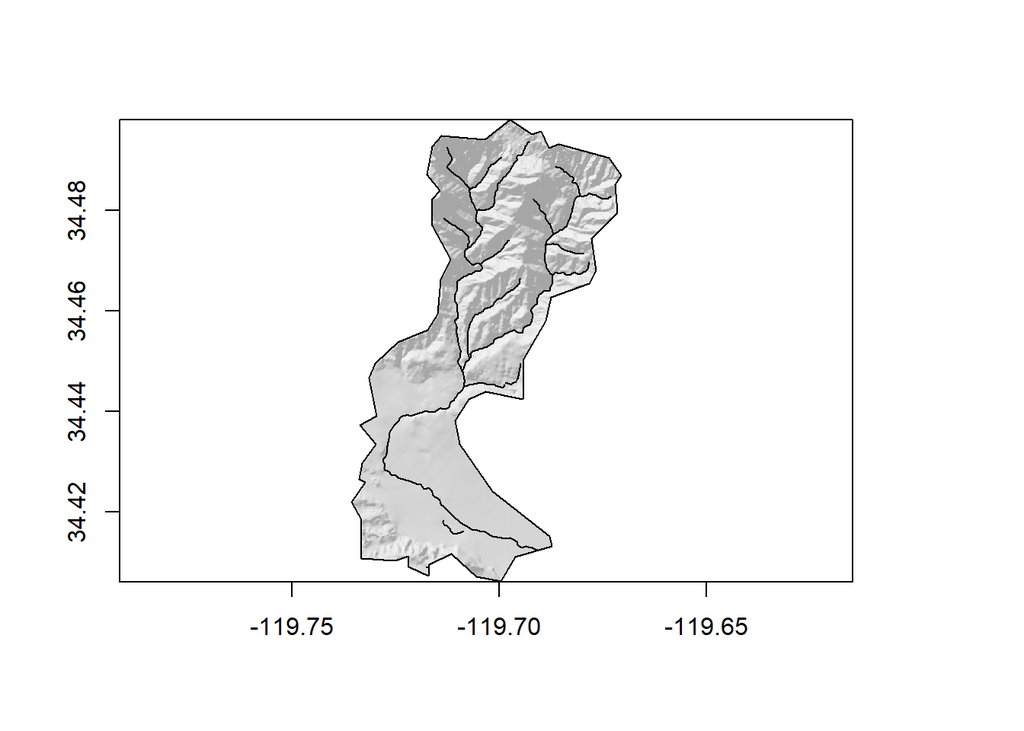

```r
Hillshade = raster("../data/terrian-near-flood-hillshade.tif")

plot(Hillshade, col= gray.colors(256, alpha = .5), legend=FALSE)
plot(Basin$geometry,add=TRUE)
plot(Rivers$geometry,add=TRUE)
```

Had to read in raster using `raster`

### Height Above Nearest Drainage

##### Creating the river raster

```r
River = st_transform(Rivers,5070) %>%
  st_buffer(10) %>%
  st_transform(crs(elevation_feet)) %>%
  fasterize::fasterize(elevation_feet) %>%
  writeRaster("../data/River.tif", overwrite=TRUE) #Saved raster
```

##### Creating the hydrologically corrected surface

```r
wbt_breach_depressions("../data/elev_raster_feet.tif", "../data/breach_depressions.tif")
```

##### Creating the HAND raster

```r
wbt_elevation_above_stream("../data/breach_depressions.tif","../data/River.tif", "../data/Elevation_above_stream.tif")
```

# Correcting to local reference datum

```r
Hand_raster = raster("../data/Elevation_above_stream.tif")+3.69
```

Read in raster for HAND & add the offset (3.69) to the entire HAND raster

```r
River_raster = raster("../data/River.tif")
```

read in raster for River

```r
Hand_raster[River_raster == 1] = 0
```

Ensured that if the cell has a value of 1 in the river raster then its HAND value is set to 0.

```r
writeRaster(Hand_raster,"../data/Corrected_tif.tif", overwrite=TRUE)
```

Saved the new, offset raster to data folder

# 2017 Impact Assessment

### Map the flood & Estimate the impacts

```r
Flood2017 = raster("../data/Corrected_tif.tif")
Flood2017_map = Flood2017
```

Read in the corrected HAND raster

```r
Flood2017_map[Flood2017_map >= 10.02] = NA
```

Created a flood map where any cell with a HAND value greater then 10.02 is set to NA.

```r
cols = ifelse(!is.na(raster::extract(Flood2017_map, Centroid)), "red", "black")
```

Colored impacted buildings

##### Created resulting map with the following plots

- Plotted my hillshade, this time with a title using `main` and inputted data into your title with `paste0`.
- Plotted flood map and building shapes with their geometries
- Plotted the railway station as a point of reference colored in green, with cex = 1, pch = 16, and added the basin outline.

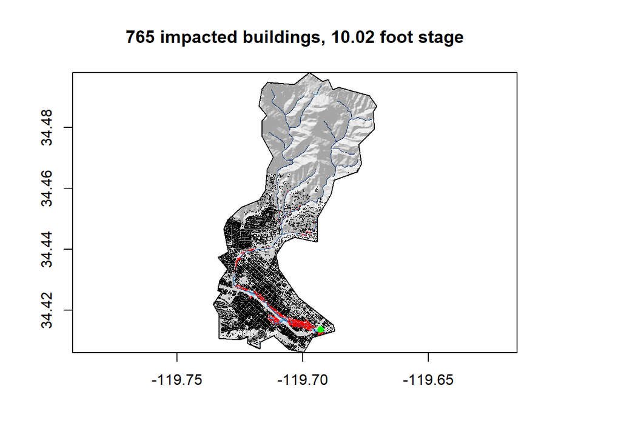

```r
plot(Hillshade, col= gray.colors(256, alpha = .5), legend=FALSE, main = paste0(sum(cols == "red"), " impacted buildings, 10.02 foot stage"))
plot(Flood2017_map, col= rev(blues9), legend=FALSE, add=TRUE)
plot(Centroid$geometry, add = TRUE, col = cols, pch = 16, cex=.08)
plot(Railroad$geometry, col= "green", cex=1, pch=16, add = TRUE)
plot(Basin$geometry, add = TRUE, border = "black")
```

### Does that map look accurate?

- Yes, it does.

# Extra Credit

### Flood Inudation Map library

```r
sb = AOI::aoi_get("Santa Barbara")
gif_flood = crop(Flood2017, sb) # cropping by comparing raster to vector
basin_clip = st_intersection(Basin, sb) # cropping by comparing vector to vector
hill_crop = crop(Hillshade, sb)
```

### Gif Creation

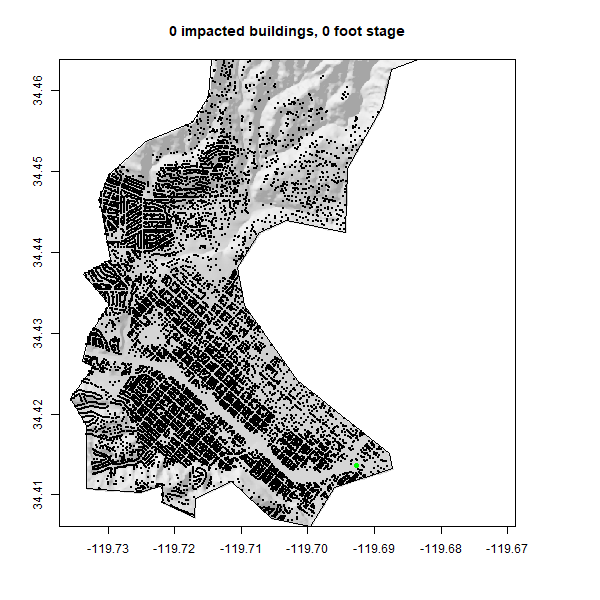

Gif

```r
gifski::save_gif({
  for(i in 0:20) {
    tmp = gif_flood
    tmp[tmp >= i] = NA
    cols = ifelse(!is.na(raster::extract(tmp, Centroid)), "red", "black")
    plot(hill_crop, col= gray.colors(256, alpha = .5), legend=FALSE, main = paste0(sum(cols == "red"), " impacted buildings, ", i, " foot stage"))
    plot(tmp, col= rev(blues9), legend=FALSE, add=TRUE)
    plot(Centroid$geometry, add = TRUE, col = cols, pch = 16, cex=.08)
    plot(Railroad$geometry, col= "green", cex=1, pch=16, add = TRUE)
    plot(basin_clip$geometry, add = TRUE, border = "black")
  }
}, gif_file = "../data/mission-creek-fim.gif",
   width = 600, height = 600,
   delay = .7, loop = TRUE)
```